# Laboratorio 1

Federico Daverio

# R y Rstudio

R es un software libre diseñado para análisis estadisticos y gráficas. Se hizo popular siendo que su curva de aprendizaje es relativamente más empinada con respecto a otros lenguajes de programación. A pesar de esto Stata sigue siendo el software más utilziado en el analisís economico, pero es de pega y su licencia es muy cara 8por lo menos para mi ;) )

Una de las caracterristica peculiares es que resulta ser un proyecto colaborativo donde estudiosos de distitntas partes del mundo pueden aportar al enriquecimiento de las funciones de este software por medios de paquetes. Enb particular los más actualziados y estables se pueden encontrar en [CRAN](https://cran.r-project.org/).

R es el lenguaje de programación y si tuvieramos que utilizarlo puro sería solo por medio de una consola. Al contrario R studio es un programa que permite utilizar R de manera más comoda y efectiva. R studio es un IDE, ósea un entorno de desarrollo integrado. Esto significa que es un sistema de software para el diseño de aplicaciones que combina herramientas del desarrollador comunes en una sola interfaz gráfica de usuario (GUI).

# Lo basico

Hay algunas cosas que vale la pena hacer antes de empezar a trabajar. La primera es limpiar nuestra sesión eliminando todos los objetos y variables en memoria:

```r
rm(list=ls())
```

Luego definimos la directory donde iremos trabajando:

```r
setwd("C:/DAVE2/CIDE/Doc/Econometria II/Web")
```

Si preferimos podemos evitar el utilizo de la notación cientifica de default:

```r
options(scipen=999)
```

Y pasar los elementos graficos a una ventana independiente:

```r
options(device = "windows")
dev.new()
```

## Los paquetes

Como vimos en CRAN hay muchos paquetes que nos sirven para ampliar las funcionalides basicas de R (i.e hacer PSM, regresiones con efectos fijos, estimaciones de IC en presencia de heteroscedasticidad). Cuando queremos instalar un nuevo paquete podemos hacerlo a traves del ide de la siguiente forma:

```
Tools -> Install packages -> seleccionamo CRAN -> seleccionamos el paquete que nos interes
```

De otra forma podemos hacerlo directamente en el codigo:

```
install.packages("nombre paquete")
```

Cuando un paquete es ya instalado, es suficiente instalarlo solo la primera vez que lo utilizamos, en la siguientes sesiones o cuando queremos utilizarlo será suficiente solo cargarlo:

```r
library(tidyverse)
```

## Constantes y operaciones

Cuando queremos asignar un valor a una constante lo haremos de la siguiente forma:

```r
a<-6
b<-7
```

El sistema asignará a las constantes designada los valores correspectivos y podremos utilizarlas para hacer las operaciones que queremos:

```r
c<- a+b
d<- a-b
e<- a*b
f<- a/b
g<- a^b
```

Que resultados obtendremos?

```r
c
```

```
## [1] 13
```

```r
d
```

```
## [1] -1
```

```r
e
```

```
## [1] 42
```

```r
f
```

```
## [1] 0.8571429
```

```r
g
```

```
## [1] 279936
```

Para imprimir un elemento es suficiente escribirlo en el editor del codigo o en la consola.

### Ejercicio 1

Un rectangulo tiene una base igual a 10 unidades y una altura igual a 4 unidades. Genere una constante llamada *area.rect* que indique el area del rectangulo

**Solución**

```r
area.rect <- 10*4
area.rect
```

```
## [1] 40
```

```r
base <- 10
altura <- 4
area.rect <- base*altura
```

### Ejercicio 2

¿Que pasa si el rectangulo ahora tiene una altura de 5? Genere la nueva area *area.rect.2*

**Solución**

```r
altura <- 5
area.rect.2 <- base*altura
```

Notense que cuando volvemos a asignar una misma variable, el valor precedente se pierde.

### Ejercicio 3

Un circulo tiene radio de 2.6. Genere una constante *a.circ* que indique el area del circulo y otra *p.circ* que indique la circunferencia

**Solución**

```r
radio <- 2.6
d.circ <- radio^2*pi
p.circ <- pi*2*radio
```

Vemos que algunas constante ya vienen pre asignada en R y en su sintaxis

## vectores y matrices

Podemos definir un vector de la siguiente forma

```r
x<-c(3,4,5)
```

Podemos hacer operaciones con los vectores, como multiplicarlo por un escalar:

```r
xx<-x*2
xx
```

```
## [1]  6  8 10
```

Nuestros vectores pueden ser compuestos por cadenas:

```r
y <- c("Pedro", "Andrea", "Ana")
y
```

```
## [1] "Pedro"  "Andrea" "Ana"
```

Para obtner una matriz especificamos un vector y las dimeniones de la matriz misma:

```r
M <- matrix(data=c(4,-2,1,6,0,5),nrow=2,ncol=3)
M
```

```
##      [,1] [,2] [,3]
## [1,]    4    1    0
## [2,]   -2    6    5
```

No es necesario siempre especificar el nombre del argumento:

```r
N <- matrix(c(4,-2,1,6,0,5),2,3)
N
```

```
##      [,1] [,2] [,3]
## [1,]    4    1    0
## [2,]   -2    6    5
```

Se pueden hacer operaciones con las matrices así como hicimos con los vectores:

```r
N2 <- N*2
N2
```

```
##      [,1] [,2] [,3]
## [1,]    8    2    0
## [2,]   -4   12   10
```

## Operaciones basicas

R incluye en su funciones basicas unas para obtener informaciones estadisticas con respecto a nuestras variables (i.e. vectores)

Media

```r
mean(x)
```

```
## [1] 4
```

si no conocemos la sintaxis y las caracteristicas de una funcion podemos utilizar la siguiente expresión:

```r
?mean
```

```
## starting httpd help server ... done
```

Mediana, Varianza, Desviación Estandar, Standard Score (Z-Score)

```r
median(x)
```

```
## [1] 4
```

```r
var(x)
```

```
## [1] 1
```

```r
sd(x)
```

```
## [1] 1
```

```r
scale(x)
```

```
##      [,1]
## [1,]   -1
## [2,]    0
## [3,]    1
## attr(,"scaled:center")
## [1] 4
## attr(,"scaled:scale")
## [1] 1
```

Ahora bien vemos como graficar una curva sencilla con ggplot

```r
library(ggplot2)
x <- c(-4,-3,-2,-1,0,1,2,3,4)
y<-x^2
```

Que curva obtendremos?

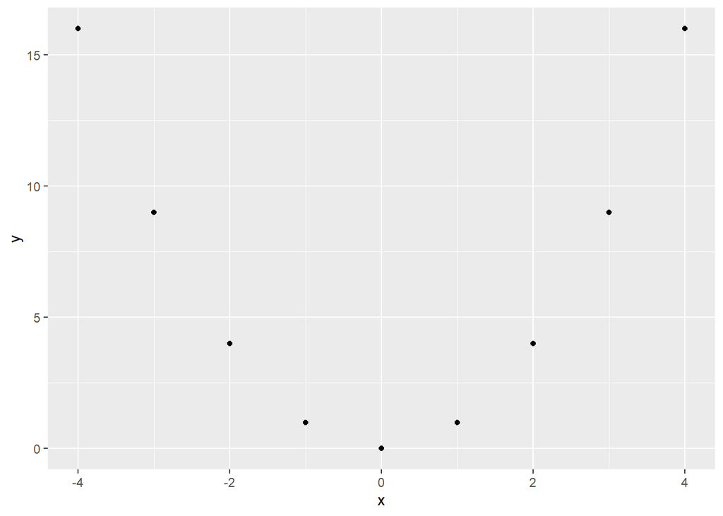

```r
qplot(x, y)
```

## Leer Base de datos

Vimos precedentemente que hemos fijado nuestro directorio de trabajo. Si la base que queremos cargar está en la misma carpeta para leer un archivo es suficiente a apuntar a esta directory poniendo adelante del nombre del archivo *./*. Recuerdense que a diferencia de windows y stata tendremos que utilizar el slash al reves:

```r
library(tidyverse)
mundata <- read_csv(file = "./mundata.csv")
```

Siquermos leer caracteres en español, podemos especificar el encodimg:

```r
mundata <- read_csv(file = "./mundata.csv",
                    locale = locale(encoding = "latin1"))
```

Esta base de datos presenta los datos de la población de los municipios de México. Además presenta el numero de cama y unidades de cuidado intensivo de acuerdo a los ultimos registros oficiales.

Para explorar la base de datos podemos ver el nombbre de las columnas:

```r
colnames(mundata)
```

```
## [1] "clave"     "clave_ent" "nom_ent"   "mun"       "pop"       "icu"
## [7] "beds"      "cve_sun"   "nom_sun"
```

Las primeras filas:

```r
head(mundata)
```

```
## # A tibble: 6 x 9
##   clave clave_ent nom_ent        mun           pop   icu  beds cve_sun nom_sun
##   <dbl>     <dbl> <chr>          <chr>       <dbl> <dbl> <dbl> <chr>   <chr>
## 1  1001         1 Aguascalientes Aguascali~ 961977    44  1022 M01.01  Aguascal~
## 2  1002         1 Aguascalientes Asientos    50864     0     0 <NA>    <NA>
## 3  1003         1 Aguascalientes Calvillo    60760     0    30 <NA>    <NA>
## 4  1004         1 Aguascalientes Cosío       16918     0     0 <NA>    <NA>
## 5  1005         1 Aguascalientes Jesús Mar~ 130184    12   144 M01.01  Aguascal~
## 6  1006         1 Aguascalientes Pabellón ~  50032     0    30 <NA>    <NA>
```

De las cuales podemos especificar el numero exacto de filas a visualizar:

```r
head(mundata, n=10)
```

```
## # A tibble: 10 x 9
##    clave clave_ent nom_ent        mun          pop   icu  beds cve_sun nom_sun
##    <dbl>     <dbl> <chr>          <chr>      <dbl> <dbl> <dbl> <chr>   <chr>
##  1  1001         1 Aguascalientes Aguascal~ 961977    44  1022 M01.01  Aguascal~
##  2  1002         1 Aguascalientes Asientos   50864     0     0 <NA>    <NA>
##  3  1003         1 Aguascalientes Calvillo   60760     0    30 <NA>    <NA>
##  4  1004         1 Aguascalientes Cosío      16918     0     0 <NA>    <NA>
##  5  1005         1 Aguascalientes Jesús Ma~ 130184    12   144 M01.01  Aguascal~
##  6  1006         1 Aguascalientes Pabellón~  50032     0    30 <NA>    <NA>
##  7  1007         1 Aguascalientes Rincón d~  57981     0    30 <NA>    <NA>
##  8  1008         1 Aguascalientes San José~   9661     0     0 <NA>    <NA>
##  9  1009         1 Aguascalientes Tepezalá   22743     0     0 <NA>    <NA>
## 10  1010         1 Aguascalientes El Llano   21947     0     0 <NA>    <NA>
```

Podemos tambvién imprmir las ultimas observaciones:

```r
tail(mundata)
```

```
## # A tibble: 6 x 9
##   clave clave_ent nom_ent   mun             pop   icu  beds cve_sun nom_sun
##   <dbl>     <dbl> <chr>     <chr>         <dbl> <dbl> <dbl> <chr>   <chr>
## 1 32053        32 Zacatecas Villa Gonzá~  13945     0     0 <NA>    <NA>
## 2 32054        32 Zacatecas Villa Hidal~  20177     0     0 <NA>    <NA>
## 3 32055        32 Zacatecas Villanueva    31804     0    22 <NA>    <NA>
## 4 32056        32 Zacatecas Zacatecas    155533    24   337 M32.01  Zacatecas-G~
## 5 32057        32 Zacatecas Trancoso      20285     0    12 M32.01  Zacatecas-G~
## 6 32058        32 Zacatecas Santa María~   2855     0     0 <NA>    <NA>
```

O averiguar el tamaño de nuestro dataframe:

```r
dim(mundata)
```

```
## [1] 2457    9
```

Si quermos saber el numero de filas de nuestra matriz podemos utilizar la siguinete función:

```r
nrow(mundata)
```

```
## [1] 2457
```

Mintras para las columnas será:

```r
ncol(mundata)
```

```
## [1] 9
```

Para saber la estructura de nuestro database podemos utilizar:

```r
str(mundata)
```

```
## spec_tbl_df [2,457 x 9] (S3: spec_tbl_df/tbl_df/tbl/data.frame)
##  $ clave    : num [1:2457] 1001 1002 1003 1004 1005 ...
##  $ clave_ent: num [1:2457] 1 1 1 1 1 1 1 1 1 1 ...
##  $ nom_ent  : chr [1:2457] "Aguascalientes" "Aguascalientes" "Aguascalientes" "Aguascalientes" ...
##  $ mun      : chr [1:2457] "Aguascalientes" "Asientos" "Calvillo" "Cosío" ...
##  $ pop      : num [1:2457] 961977 50864 60760 16918 130184 ...
##  $ icu      : num [1:2457] 44 0 0 0 12 0 0 0 0 0 ...
##  $ beds     : num [1:2457] 1022 0 30 0 144 ...
##  $ cve_sun  : chr [1:2457] "M01.01" NA NA NA ...
##  $ nom_sun  : chr [1:2457] "Aguascalientes" NA NA NA ...
##  - attr(*, "spec")=
##   .. cols(
##   ..   clave = col_double(),
##   ..   clave_ent = col_double(),
##   ..   nom_ent = col_character(),
##   ..   mun = col_character(),
##   ..   pop = col_double(),
##   ..   icu = col_double(),
##   ..   beds = col_double(),
##   ..   cve_sun = col_character(),
##   ..   nom_sun = col_character()
##   .. )
##  - attr(*, "problems")=<externalptr>
```

## Base de datos

Podemos filtrar nuestra base de datos:

```r
filter(mundata, clave_ent==2)
```

```
## # A tibble: 5 x 9
##   clave clave_ent nom_ent         mun            pop   icu  beds cve_sun nom_sun
##   <dbl>     <dbl> <chr>           <chr>        <dbl> <dbl> <dbl> <chr>   <chr>
## 1  2001         2 Baja California Ensenada    5.36e5    14   520 M02.01  Ensena~
## 2  2002         2 Baja California Mexicali    1.09e6    32  1101 M02.02  Mexica~
## 3  2003         2 Baja California Tecate      1.14e5     0   112 M02.03  Tijuana
## 4  2004         2 Baja California Tijuana     1.79e6    29  2189 M02.03  Tijuana
## 5  2005         2 Baja California Playas de ~ 1.08e5     0    64 M02.03  Tijuana
```

POdemos asignar la selección a una nueva variable:

```r
mun.bc <- filter(mundata, clave_ent==2)
```

Se pueden poenr más de una condición:

```r
mun.peninsula.baja <- filter(mundata, clave_ent==2 | clave_ent==3)
```

podemos seleccionar los estados de la frontera norte:

```r
estados.frontera <- c("Baja California",
                      "Sonora",
                      "Chihuahua",
                      "Coahuila",
                      "Nuevo León",
                      "Tamaulipas")
```

El operador *%in%* indica pertenencia a un conjunto:

```r
mun.frontera <- filter(mundata, nom_ent %in% estados.frontera)
```

```r
summarise(mun.frontera, mpop=mean(pop))
```

```
## # A tibble: 1 x 1
##     mpop
##    <dbl>
## 1 83299.
```

### Ejercicio 4

- Crea un nuevo objeto que tenga a los municipios del Estado de México llamado “México” en la base de datos) y que además tenga más de 10,000 habitantes
- Crea otro objeto que tenga a los municipios en los estados de la frontera y que tengan cada uno mÃ¡s de 100 camas de hospital (beds)
- Crea un nuevo objeto que tenga a todos los municipios de México que tengan entre 10 y 20 UCI

**Solución**

```r
mun.edo.mex <- filter(mundata, nom_ent=="MÃ©xico" & pop>10000)


mun.frontera.camas <- filter(mundata, nom_ent %in% estados.frontera & beds>100)

mun.uci <- filter(mundata, icu>=10 & icu <=20)
```

## Ordenamiento y selecciñon

Arrange srive para ordenar los datos de acuerdo a una variable

```r
arrange(mun.bc, beds)
```

```
## # A tibble: 5 x 9
##   clave clave_ent nom_ent         mun            pop   icu  beds cve_sun nom_sun
##   <dbl>     <dbl> <chr>           <chr>        <dbl> <dbl> <dbl> <chr>   <chr>
## 1  2005         2 Baja California Playas de ~ 1.08e5     0    64 M02.03  Tijuana
## 2  2003         2 Baja California Tecate      1.14e5     0   112 M02.03  Tijuana
## 3  2001         2 Baja California Ensenada    5.36e5    14   520 M02.01  Ensena~
## 4  2002         2 Baja California Mexicali    1.09e6    32  1101 M02.02  Mexica~
## 5  2004         2 Baja California Tijuana     1.79e6    29  2189 M02.03  Tijuana
```

```r
mun.bc <- arrange(mun.bc, beds)
```

Si añadimos la opcion desc obtenemos el orden descendente

```r
mun.bc <- arrange(mun.bc, desc(beds))
```

Select permite seleccionar variables (columnas)

```r
pob.mun <- select(mundata, clave, pop)
```

Mutate permite crear nuevas variables o columnas

```r
mundata <- mutate(mundata, recursos=beds+icu)
```

if_else nos permite evaluar condicionales (lo veremos de nuevo en funciones)

```r
mundata <- mutate(mundata,
                  frontera=ifelse(nom_ent %in% estados.frontera, 1, 0))
```

### Ejercicio 5

#Genere un objeto que contenga los municipios del centro del pais (Ciudad de México, Estado de México, Puebla, Tlaxcala y Morelos)

En el nuevo objeto, genere una nueva variable que indique el logaritmo natural del numero de camas de hospital por cada 100,000 habitantes en dichos municipios

**Solución**

```r
estados.centro <- c("Ciudad de MÃ©xico",
                    "MÃ©xico",
                    "Puebla",
                    "Tlaxcala",
                    "Morelos")

mun.centro <- filter(mundata, nom_ent %in% estados.centro)



mun.centro <- mutate(mun.centro,
                     lcamas100=log(beds*100000/pop))
```

## Mas de dply

Con summarise podemos obtener estadisticas basicas:

Media

```r
summarise(mundata, media.pop=mean(pop))
```

```
## # A tibble: 1 x 1
##   media.pop
##       <dbl>
## 1    52012.
```

Desviacion Estadar

```r
summarise(mundata, sd.pop=sd(pop))
```

```
## # A tibble: 1 x 1
##    sd.pop
##     <dbl>
## 1 147554.
```

Con group_by podemos implementar funciones por subgrupos

```r
por_estado <- group_by(mundata,clave_ent)
summarise(por_estado, media.pop=mean(pop))
```

```
## # A tibble: 32 x 2
##    clave_ent media.pop
##        <dbl>     <dbl>
##  1         1   130421.
##  2         2   726974.
##  3         3   160942.
##  4         4    90965.
##  5         5    84703.
##  6         6    78515.
##  7         7    48562.
##  8         8    56739.
##  9         9   563665.
## 10        10    47923.
## # ... with 22 more rows
```

Creamos un nuevo objeto con la media por estado

```r
medias.estado <- summarise(por_estado, media.pop=mean(pop))
```

## Variables de factores

Volvemos a cargar los datos para tener nuestra base original

```r
mundata <- read_csv(file = "./mundata.csv",
                    locale = locale(encoding = "latin1"))
```

Seleccionamos todas las columnas de nuestro interes

```r
mundata <- select(mundata,
                  -c("cve_sun","nom_sun"))
```

Generemos una nueva variable llamada region que tome los valores de acuerdo a la definiciÃ³n de regiones siguiente: * 1 para la region * 2 para la region centro * 3 para la region centro-occidente * 4 para la region sureste

```r
estados.norte <- c("Baja California",
                   "Baja California Sur",
                   "Chihuahua",
                   "Coahuila",
                   "Durango",
                   "Nuevo León",
                   "Sinaloa",
                   "Sonora",
                   "Tamaulipas")

estados.centro <- c("Ciudad de México",
                    "Guerrero",
                    "Hidalgo",
                    "México",
                    "Morelos",
                    "Puebla",
                    "Tlaxcala",
                    "Oaxaca")

estados.centroocc <- c("Aguascalientes",
                       "Colima",
                       "Guanajuato",
                       "Jalisco",
                       "MichoacÃ¡n",
                       "Nayarit",
                       "QuerÃ©taro",
                       "San Luis Potosí",
                       "Zacatecas")

estados.sureste <- c("Campeche",
                     "Chiapas",
                     "Quintana Roo",
                     "Tabasco",
                     "Veracruz",
                     "Yucatán")
```

Creamos entonces una variable categorica para las cuatro regiones. Creamos una variable del 1 al 4 para las regiones

Usamos la función *case_when*

```r
mundata <- mutate(mundata,
                  region=case_when(nom_ent %in% estados.norte ~ 1,
                                   nom_ent %in% estados.centro ~ 2,
                                   nom_ent %in% estados.centroocc ~ 3,
                                   nom_ent %in% estados.sureste ~ 4))
```

Construimos un objeto que reporte el promedio del numero de camas por cada 100,000 habitantes de los municipios, por region

```r
mundata <- mutate(mundata, camas100=beds*100000/pop)
por_region <- group_by(mundata,region)

camas.region <- summarise(por_region, media.camas100=mean(camas100))
```

Convertimos region a factor

```r
mundata <- mutate(mundata,
                  region=factor(region,
                                levels = c(1,2,3,4),
                                labels = c("RegiÃ³n Norte",
                                           "RegiÃ³n Centro",
                                           "RegiÃ³n Centro-Occidente",
                                           "Region Sureste")))

levels(mundata$region)
```

```
## [1] "RegiÃ³n Norte"            "RegiÃ³n Centro"
## [3] "RegiÃ³n Centro-Occidente" "Region Sureste"
```

## La pipa

Haremos en un paso lo siguiente: nos quedaremos con un objeto de los municipios de la Region Centro, creamos una variable que sume las camas y las UCI, generamos una variable que indique que el municipio tiene recursos bajos si tiene menos de 100 recursos de salud y, finalmente, que nos de la proporcion de municipios por estado que se consideran de recursos bajos

```r
mundata %>%
  filter(region=="RegiÃ³n Centro") %>%
  mutate(recursos_totales=beds+icu) %>%
  mutate(recursos_bajos=ifelse(recursos_totales<100,1,0)) %>%
  group_by(nom_ent) %>%
  summarize(prop.bajos=mean(recursos_bajos)) %>%
  ungroup()
```

```
## # A tibble: 8 x 2
##   nom_ent          prop.bajos
##   <chr>                 <dbl>
## 1 Ciudad de México      0.125
## 2 Guerrero              0.926
## 3 Hidalgo               0.905
## 4 México                0.8
## 5 Morelos               0.879
## 6 Oaxaca               NA
## 7 Puebla                0.940
## 8 Tlaxcala              0.933
```

Ponemos lo anterior en un objeto

```r
rec.bajos.centro <- mundata %>%
  filter(region=="Región Centro") %>%
  mutate(recursos_totales=beds+icu) %>%
  mutate(recursos_bajos=ifelse(recursos_totales<100,1,0)) %>%
  group_by(nom_ent) %>%
  summarize(prop.bajos=mean(recursos_bajos)) %>%
  ungroup()
```

Podemos trabajar con NA

```r
rec.bajos.centro <- mundata %>%
  filter(region=="Región Centro") %>%
  mutate(recursos_totales=beds+icu) %>%
  mutate(recursos_bajos=ifelse(recursos_totales<100,1,0)) %>%
  group_by(nom_ent) %>%
  summarize(prop.bajos=mean(recursos_bajos, na.rm=TRUE)) %>%
  ungroup()
```

## Manejo bases

cargamos una nueva base con la Población municipal en dos bases de datos del CONAPO:

```r
library(janitor)
filename<-"./base_municipios_final_datos_01.csv"
popdata1 <- read_csv(file=filename,
                     locale = locale(encoding = "latin1"))   %>%
  clean_names() %>%
  filter(ano==2020)
filename<-"./base_municipios_final_datos_02.csv"
popdata2 <- read_csv(file = filename,
                     locale = locale(encoding = "latin1"))   %>%
  clean_names() %>%
  filter(ano==2020)
```

Apilamos las bases:

```r
mundata <- bind_rows(popdata1,popdata2)
```

Creamos una base a nivel municipal sumando dentro de cada municipio las filas de hombres y mujeres y los grupos de edad

```r
mundata <- mundata %>%
  select(-c(renglon)) %>%
  mutate(nom_ent=ifelse(clave_ent==20,"Oaxaca",nom_ent)) %>%
  group_by(clave, clave_ent, nom_ent, mun) %>%
  summarize(pop=sum(pob,na.rm=TRUE)) %>%
  arrange(clave) %>%
  ungroup()
```

Otro pequeños ejercicios con los recursos de salud publicos

```r
filename<-"./Recursos_Salud_2018.csv"

icudata <- read_csv(file=filename,
                    locale = locale(encoding = "latin1"))  %>%
  select(c("Clave Estado", "Clave Municipio", "Número de camas en la Unidad de Cuidados Intensivos (incluye pediátricas y adulto)")) %>%
  rename("cve_edo"="Clave Estado",
         "cve_mun"="Clave Municipio",
         "icu"="Número de camas en la Unidad de Cuidados Intensivos (incluye pediátricas y adulto)") %>%
  mutate(clave = str_c(cve_edo, cve_mun)) %>%
  mutate(clave=as.numeric(clave)) %>%
  group_by(clave) %>%
  summarize(icu=sum(icu,na.rm=TRUE)) %>%
  ungroup()
```

Para obtener los recursos publicos y privados

```r
filename<-"./ESTABLECIMIENTO_SALUD_202003.csv"
bedsdata <- read_csv(file = filename,
                     locale = locale(encoding = "latin1")) %>%
  select(c("CLAVE DE LA ENTIDAD", "CLAVE DEL MUNICIPIO", "CAMAS EN AREA DE HOS")) %>%
  rename("cve_edo"="CLAVE DE LA ENTIDAD",
         "cve_mun"="CLAVE DEL MUNICIPIO",
         "beds"="CAMAS EN AREA DE HOS") %>%
  mutate(clave = str_c(cve_edo, cve_mun)) %>%
  mutate(clave=as.numeric(clave)) %>%
  group_by(clave) %>%
  summarize(beds=sum(beds,na.rm=TRUE)) %>%
  ungroup()
```

Pegamos la base de UCI y de camas usando la clave del municipio:

```r
hospitaldata <- left_join(icudata, bedsdata, by="clave")
```

Con datos del sistema urbano nacional (SUN)

```r
filename<-"./Base_SUN_2018.csv"
sundata <- read_csv(file = filename,
                    locale = locale(encoding = "latin1"))   %>%
  clean_names() %>%
  mutate(tsun=substring(cve_sun,first=1,last=1)) %>%
  filter(tsun=="M") %>%
  select(-c("cve_ent", "cve_loc", "nom_loc", "pob_2018","tsun", "nom_ent","nom_mun")) %>%
  mutate(clave=as.numeric(cve_mun)) %>%
  select(-c("cve_mun"))
```

Finalmente la Base municipal será:

```r
mundata <- left_join(mundata,hospitaldata, by="clave")
mundata <- left_join(mundata,sundata, by="clave")
```

Para guardar un archivo en .csv haremos

```r
write.csv(mundata,"./base_ejercicio.csv",
          row.names = FALSE)
```

# Funciones

Las funciones son objetos que nos permiten hacer determinadas acciones pasandole cada vez distintos argumento.

Definamos la función para calcular el area de un circulo.

Esta funcion tiene un solo argumento, pues necesito un solo ingrediente para conocer el area de un circulo: su radio

```r
area_circ <- function(radio){
  return(pi*radio^2)
}
```

La aplicamos para un circulo de radio 7

```r
area_circ(radio=7)
```

```
## [1] 153.938
```

La función puede ser aplicada a cualquier objeto que represente el radio de un circulo (lo que a veces llamamos “pasar”)

```r
r <- 4
area_circ(radio=r)
```

```
## [1] 50.26548
```

Que equivale a:

```r
area_circ(r)
```

```
## [1] 50.26548
```

### Ejercicio 6

Genere una funcion para calcular el area de un rectangulo y aplicala en caso de un rectangulo con base 6 y altura 4

**Solución**

```r
area_rect <- function(base, altura){
  return(base*altura)
}


area_rect(base=6,altura=4)
```

```
## [1] 24
```

```r
area_rect(6, 4)
```

```
## [1] 24
```

Que pasaría si le paso solo un argumento?

```r
#area_rect(altura=4)
```

## Numeros aleatorios

Generemos un vector aleatorio

```r
x <- runif(20,0,100)
mean(x)
```

```
## [1] 53.46325
```

¿Que pasa si lo volvemos a generar

```r
x <- runif(20,0,100)
mean(x)
```

```
## [1] 52.42434
```

Siendo que tenemos una componente aleatoria fijamos una semilla para poder replicar los numeros (semi) aleatorios

```r
set.seed(123)
x <- runif(20,0,100)
mean(x)
```

```
## [1] 55.08084
```

Y si los volvemos a generar

```r
x <- runif(20,0,100)
mean(x)
```

```
## [1] 57.67208
```

Simulamos una base de datos

```r
datos <- tibble(
  a = rnorm(100),
  b = rnorm(100),
  c = rnorm(100),
  d = rnorm(100))
```

Y obtenemos su media y varainza:

```r
mean(datos$a)
```

```
## [1] -0.009794948
```

```r
sd(datos$a)
```

```
## [1] 0.881015
```

## Estandardizacion

A veces necesitamos presentar las variables estandardizadas, osea con media cero y desciacion estandar 1

```r
datos.modificados <- datos %>%
  mutate(a=(a-mean(datos$a))/sd(datos$a))
```

Controlamos los resultados

```r
mean(datos.modificados$a)
```

```
## [1] -0.00000000000000001141665
```

```r
sd(datos.modificados$a)
```

```
## [1] 1
```

Podemos crear una función que estandardice cada variables

```r
estandarizar <- function(insumo1){
  nuevo.dato <- (insumo1-mean(insumo1))/sd(insumo1)
}
```

La ocupamos por lo tanto para crear nuestras nuevas columnas con los datos standardizados

```r
datos.estandarizados <- datos %>%
  mutate(a=estandarizar(a)) %>%
  mutate(b=estandarizar(b)) %>%
  mutate(c=estandarizar(c)) %>%
  mutate(d=estandarizar(d))
```

Calculamos de nuevo media y varianza

```r
mean(datos.estandarizados$d)
```

```
## [1] 0.00000000000000001361758
```

```r
sd(datos.estandarizados$d)
```

```
## [1] 1
```

## Estructuras de control

Creamos una funcion para para sacar el promedio de un vector de calificaciones

```r
promedio.cide <- function(calificaciones) {
  mean(calificaciones)
}
```

Dado un vector de calificaciones

```r
profes <- c(7,7.6,8.1,9.0)
```

Pasamos ahora el vector a la funcion

```r
promedio.cide(calificaciones=profes)
```

```
## [1] 7.925
```

A veces pero algun profesor no entrega a tiempo

```r
profes.tarde <- c(7,7.6,8.1,NA)
```

Como esta nuestra funcion, el resultado es…

```r
promedio.cide(profes.tarde)
```

```
## [1] NA
```

Tenemos por lo tanto arreglar la función

```r
promedio.cide2 <- function(calificaciones) {
  mean(calificaciones, na.rm=T)
}
```

Y tendremos:

```r
promedio.cide2(profes.tarde)
```

```
## [1] 7.566667
```

# if

La condición if la usamos if para evaluar si una condición es cierta, podemos combianrlas con el uso de los operadores logicos clasicos.

```r
mensaje.alumno <- function(calificaciones) {

  media <- mean(calificaciones)

  if(media>=8) {
    print("Aprobado")
  }
  else {
    print("Reprobado")
  }
}
```

Por lo tanto tenremos que:

```r
mensaje.alumno(profes)
```

```
## [1] "Reprobado"
```

Si pero pasamos un vector de calificaciones distinto, obtendremos:

```r
profes.SS.cide <- c(9.5, 9, 10, 9.2)

mensaje.alumno(profes.SS.cide)
```

```
## [1] "Aprobado"
```

Podemos crear mensajes más complicados

```r
mensaje.complejo.alumno <- function(calificaciones) {
  media <- mean(calificaciones)
  if(is.na(media)) {
    print("Nervio")
  }
  else{
    if(media>=8) {
      print("Aprobado")
    }
    else {
      print("Reprobado")
    }
  }
}
```

Por lo tanto pasando el primer vector a la nueva función obtendremos:

```r
mensaje.complejo.alumno(profes.tarde)
```

```
## [1] "Nervio"
```

O en el casodel segundo vector:

```r
mensaje.complejo.alumno(profes.SS.cide)
```

```
## [1] "Aprobado"
```

# ifelse

Sirve para vectorizar el if y el else y que la comparacion se haga para cada elemento de un vector de valores

Supongamos que queremos una funcion por partes:

- Para valores menores o iguales que 0, queremos que la funcion nos regrese *-x*
- Para valores mayores que 0, queremos el cuadrado de x

```r
partes <- function(x){
  ifelse(x<=0,-x,x^2)
}
```

Creamos el cevtor de datos

```r
x <- seq(-5,5, by=0.1)
```

Aplicamos la función y plotemaos el resultados

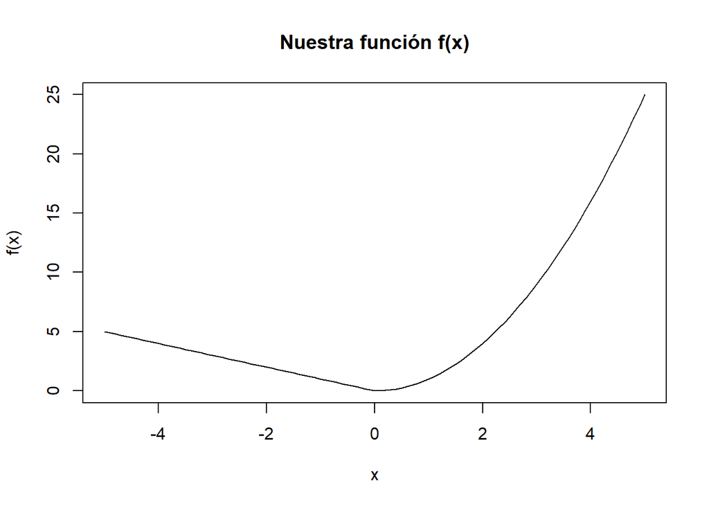

```r
resultado <- partes(x)

plot(x, resultado,
     type = "l",
     main = "Nuestra función f(x)",
     xlab = "x",
     ylab = "f(x)")
```

### Ejercicio 7

Para el siguiente vector de promedios de alumnos, use ifelse para encontrar el mensaje que se le dara a cada uno

**Solución**

```r
promedios.del.grupo <- c(7,8.2,8.0,9.2,7.3)

mensaje.grupo <- function(x){
  ifelse(x>=8, "Aprobado", "Reprobado")
}

#Y entonces:
mensaje.grupo(promedios.del.grupo)
```

```
## [1] "Reprobado" "Aprobado"  "Aprobado"  "Aprobado"  "Reprobado"
```

# For

Nos permite realizar una operacion para un conjunto o rango de valores. A esto componemtes le conocemos como bacles, ciclos o “loops”

```r
valores <- c(-1,-2,0,1,2)

for(entrada in valores) {
  print(entrada^2)
}
```

```
## [1] 1
## [1] 4
## [1] 0
## [1] 1
## [1] 4
```

En algunas aplicaciones nos será util ir guardando los resultados de la evaluacion

```r
salida <- NULL

i <- 1
for(entrada in valores) {
  salida[i] <- entrada^2
  i <- i+1
}

salida
```

```
## [1] 1 4 0 1 4
```

Casi nunca hacemos esto pues muchas operaciones estan vectorizadas o podemos vectorizar las funciones

```r
salida.facil <- valores^2

salida.facil
```

```
## [1] 1 4 0 1 4
```

# While

Otra opción para hacer loops es el utlizo del while. Este ciclo sigue hasta que se llegue a una condicion especifica / umbral.

```r
umbral <- 5
valor <- 0

while(valor < umbral) {
  print("Todavía no.")
  valor <- valor + 1
}
```

```
## [1] "Todavía no."
## [1] "Todavía no."
## [1] "Todavía no."
## [1] "Todavía no."
## [1] "Todavía no."
```

Hay que siempre prestar atención a las condiciones de cierre del ciclo.

# La familia apply

Facilitan el trabajo: pasamos argumentos y funciones

Recordemos que tenemos

```r
head(datos)
```

```
## # A tibble: 6 x 4
##        a      b       c      d
##    <dbl>  <dbl>   <dbl>  <dbl>
## 1 -1.07   0.118 -0.574   0.237
## 2 -0.218 -0.947  0.618   1.22
## 3 -1.03  -0.491  1.11   -1.34
## 4 -0.729 -0.256  0.708   0.661
## 5 -0.625  1.84  -0.364  -0.523
## 6 -1.69  -0.652  0.0597  0.684
```

```r
mean(datos$a)
```

```
## [1] -0.009794948
```

```r
sd(datos$a)
```

```
## [1] 0.881015
```

Y que tenemos una funcion para estandarizar

```r
datos.estandarizados.facil <- apply(X = datos, MARGIN = 2, FUN = estandarizar)
```

Noten que el objeto que nos regresa apply es una matrix

```r
class(datos.estandarizados.facil)
```

```
## [1] "matrix" "array"
```

Corroboramos los resultados

```r
mean(datos.estandarizados.facil[,3])
```

```
## [1] 0.00000000000000003159853
```

```r
sd(datos.estandarizados.facil[,3])
```

```
## [1] 1
```

Recuerda,ps que siempre MARGIN se refiere a: 1==filas y 2==columnas

### Ejercicio 8

Usando apply, corrobore que en el data frame estandarizado, cada variable o columna tiene media 0 y desviacion estandar 1

**Solución**

```r
apply(datos.estandarizados.facil, 2, mean)
```

```
##                           a                           b
## -0.000000000000000011416649 -0.000000000000000007836613
##                           c                           d
##  0.000000000000000031598530  0.000000000000000013617579
```

```r
apply(datos.estandarizados.facil, 2, sd)
```

```
## a b c d
## 1 1 1 1
```

Una desventaja del apply es que nos devuelve un objeto del mismo tipo que la funcion aplicada

```r
class(datos.estandarizados.facil)
```

```
## [1] "matrix" "array"
```

De algun modo hay que ponerlo de nuevo en data frame

```r
datos.estandarizados.facil <- as_tibble(datos.estandarizados.facil)
```

Ahora nuestro objeto será:

```r
class(datos.estandarizados.facil)
```

```
## [1] "tbl_df"     "tbl"        "data.frame"
```

# lapply

Funciona como apply, pero nos devuelve una lista:

```r
datos.estandarizados.lapply <- lapply(datos, estandarizar)
```

Controlamos el tipo de objeto:

```r
class(datos.estandarizados.lapply)
```

```
## [1] "list"
```

De todas formas tenemos que convertirlo en data frame

Pero no tenemos que preocuparnos por el formato del la salida de lapply: siempre será una lista

```r
datos.estandarizados.super.facil <- as_tibble(datos.estandarizados.lapply)
```

# Exploracion Datos

## Funciones basicas

Como vimos precedentemente cuando tenemos un dataframe podemos obrtener algunas caracteristicas utiles del mismo:

```r
head(mundata)
```

```
## # A tibble: 6 x 9
##   clave clave_ent nom_ent        mun           pop   icu  beds cve_sun nom_sun
##   <dbl>     <dbl> <chr>          <chr>       <dbl> <dbl> <dbl> <chr>   <chr>
## 1  1001         1 Aguascalientes Aguascali~ 961977    44  1022 M01.01  Aguascal~
## 2  1002         1 Aguascalientes Asientos    50864     0     0 <NA>    <NA>
## 3  1003         1 Aguascalientes Calvillo    60760     0    30 <NA>    <NA>
## 4  1004         1 Aguascalientes Cosío       16918     0     0 <NA>    <NA>
## 5  1005         1 Aguascalientes Jesús Mar~ 130184    12   144 M01.01  Aguascal~
## 6  1006         1 Aguascalientes Pabellón ~  50032     0    30 <NA>    <NA>
```

```r
dim(mundata)
```

```
## [1] 2457    9
```

```r
nrow(mundata)
```

```
## [1] 2457
```

```r
ncol(mundata)
```

```
## [1] 9
```

```r
mean(mundata$beds)
```

```
## [1] NA
```

```r
mean(mundata$beds, na.rm=TRUE)
```

```
## [1] 53.1148
```

```r
mean(mundata$beds, na.rm=T)
```

```
## [1] 53.1148
```

```r
sd(mundata$beds, na.rm=T)
```

```
## [1] 269.638
```

```r
max(mundata$beds, na.rm=T)
```

```
## [1] 5337
```

Si queremos una base que indique el promedio de camas por estado:

```r
aggregate(mundata$beds,
          by=list(Estado=mundata$nom_ent),
          mean)
```

```
##                 Estado          x
## 1       Aguascalientes  114.27273
## 2      Baja California  797.20000
## 3  Baja California Sur  218.40000
## 4             Campeche   82.00000
## 5              Chiapas   29.68644
## 6            Chihuahua   68.61194
## 7     Ciudad de México 1365.87500
## 8             Coahuila   93.44737
## 9               Colima   88.30000
## 10             Durango   51.23077
## 11          Guanajuato   99.02174
## 12            Guerrero   29.04938
## 13             Hidalgo   35.16667
## 14             Jalisco   73.92000
```

[output cut: 18 more lines]

```r
mean.camas.mun <- aggregate(mundata$beds,
                            by=list(Estado=mundata$nom_ent),
                            mean)
```

El problemas es que hay nan, entonces arreglamos con na.rm:

```r
aggregate(mundata$beds,
          by=list(Estado=mundata$nom_ent),
          mean,
          na.rm=T)
```

```
##                 Estado           x
## 1       Aguascalientes  114.272727
## 2      Baja California  797.200000
## 3  Baja California Sur  218.400000
## 4             Campeche   82.000000
## 5              Chiapas   29.686441
## 6            Chihuahua   68.611940
## 7     Ciudad de México 1365.875000
## 8             Coahuila   93.447368
## 9               Colima   88.300000
## 10             Durango   51.230769
## 11          Guanajuato   99.021739
## 12            Guerrero   29.049383
## 13             Hidalgo   35.166667
## 14             Jalisco   73.920000
```

[output cut: 18 more lines]

```r
mean.camas.mun <- aggregate(mundata$beds,
                            by=list(Estado=mundata$nom_ent),
                            mean,
                            na.rm=T)
```

Tenemos que arreglar los nombres:

```r
mean.camas.mun <- set_names(mean.camas.mun, c("Estado", "media.camas"))
```

Hacemos ahora un subgrupo del data frame, tomando estados de la peninsula de Baja California

```r
mundata.baja <- subset(mundata,
                       nom_ent %in% c("Baja California","Baja California Sur"),
                       select=c(nom_ent,mun, pop, beds, icu))
```

Y luego podemos calcular la media entre municipios de cada uno de los dos estados:

```r
mean.camas.baja <- aggregate(mundata.baja$beds,
                             by=list(Estado=mundata.baja$nom_ent),
                             mean,
                             na.rm=T)
```

Y tendriamos que arreglar los nombres

Todo esto es más fácil con las pipas

```r
subset(mundata,
       nom_ent %in% c("Baja California","Baja California Sur"),
       select=c(nom_ent,mun, pop, beds, icu)) %>%
  group_by(nom_ent) %>%
  summarise(media.camas=mean(beds)) %>%
  ungroup()
```

```
## # A tibble: 2 x 2
##   nom_ent             media.camas
##   <chr>                     <dbl>
## 1 Baja California            797.
## 2 Baja California Sur        218.
```

Podemos calcular varias estadisticas

```r
tabla.desc <- subset(mundata,
                     nom_ent %in% c("Baja California","Baja California Sur"),
                     select=c(nom_ent,mun, pop, beds, icu)) %>%
  group_by(nom_ent) %>%
  summarise(media.camas=mean(beds),
            de.camas=sd(beds),
            obs.camas=n(),
            min.camas=min(beds),
            max.camas=max(beds)) %>%
  ungroup()
```

## EstadÃstica a distintos niveles

A nivel SUN

```r
sundata <- mundata %>%
  filter(!is.na(cve_sun)) %>%
  group_by(cve_sun, nom_sun) %>%
  summarise(pop=sum(pop,na.rm=TRUE),
            beds=sum(beds,na.rm=TRUE),
            icu=sum(icu,na.rm=TRUE)) %>%
  ungroup()
```

A nivel estado

```r
statedata <- mundata %>%
  group_by(clave_ent, nom_ent) %>%
  summarise(pop=sum(pop,na.rm=TRUE),
            beds=sum(beds,na.rm=TRUE),
            icu=sum(icu,na.rm=TRUE)) %>%
  arrange(clave_ent) %>%
  ungroup()
```

Total nacional

```r
statedata %>%
  summarise(pop=sum(pop,na.rm=TRUE),
            beds=sum(beds,na.rm=TRUE),
            icu=sum(icu,na.rm=TRUE))
```

```
## # A tibble: 1 x 3
##         pop   beds   icu
##       <dbl>  <dbl> <dbl>
## 1 127792286 129547  3826
```

### Ejercicio 9

**Solución**

```r
statedata.con.porcentajes <- statedata %>%
  mutate(pop.nal=sum(pop,na.rm=TRUE),
            beds.nal=sum(beds,na.rm=TRUE),
            icu.nal=sum(icu,na.rm=TRUE)) %>%
  mutate(p.pop=pop/pop.nal,
         p.beds=beds/beds.nal,
         p.icu=icu/icu.nal)
```

# Gráficos

Volvemos a cargar nuestra base de dtos para elminar todas las modificaciones

```r
mundata <- read_csv(file = "./mundata.csv",
                                      locale = locale(encoding = "latin1"))
```

Ggplot es una de las libreria más complet para garaficar. Podemos crear diferentes tipos de grafico:

Gráfico de puntos

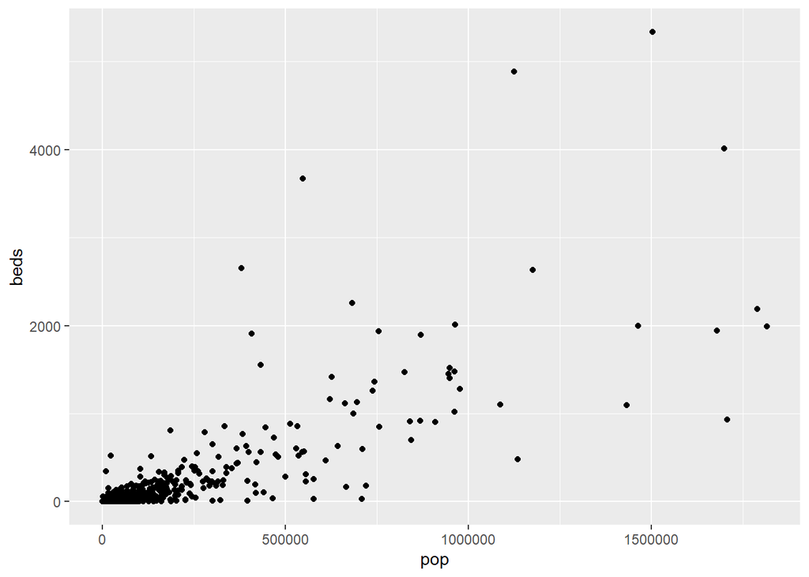

```r
ggplot(data=mundata)+
  geom_point(mapping = aes(x=pop, y=beds))
```

Podemos cambiar el color del punto

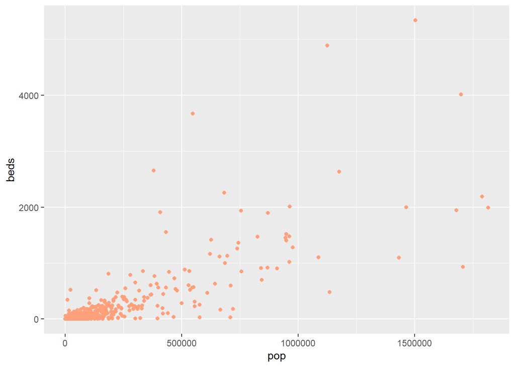

```r
ggplot(data=mundata)+
  geom_point(mapping = aes(x=pop, y=beds),
             color = "lightsalmon1")
```

Cambiamos el tamaño del marcador:

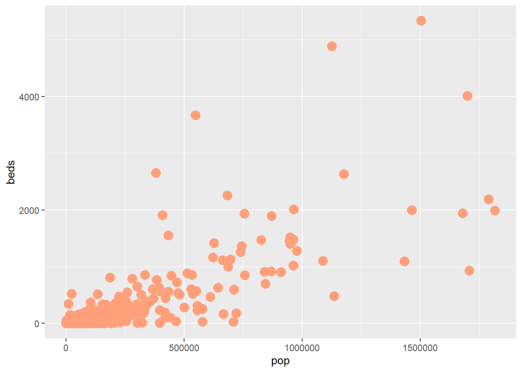

```r
ggplot(data=mundata)+
  geom_point(mapping = aes(x=pop, y=beds),
             color = "lightsalmon1",
             size = 4)
```

Graficamos la tendencia lineal

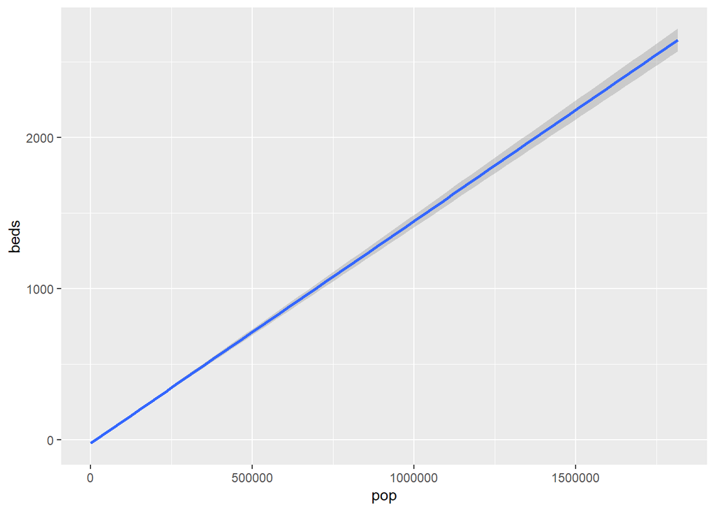

```r
ggplot(data=mundata)+
  geom_smooth(method="lm",
              mapping = aes(x=pop, y=beds))
```

PPodemos poner los dos tipos de grafico juntos:

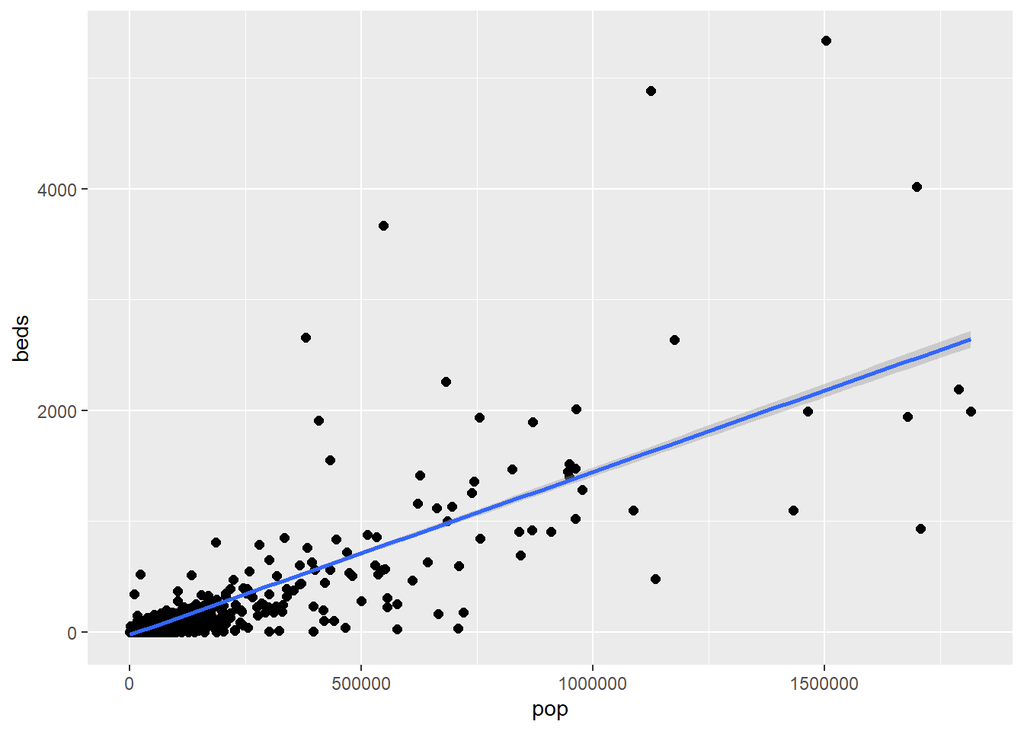

```r
ggplot(data=mundata)+
  geom_point(mapping = aes(x=pop, y=beds),
             size = 2)+
  geom_smooth(method="lm",
              mapping = aes(x=pop, y=beds))
```

La tendenciaa por defecto es un “suavizador”, que estudiaremos con detalle en metodos no parametricos

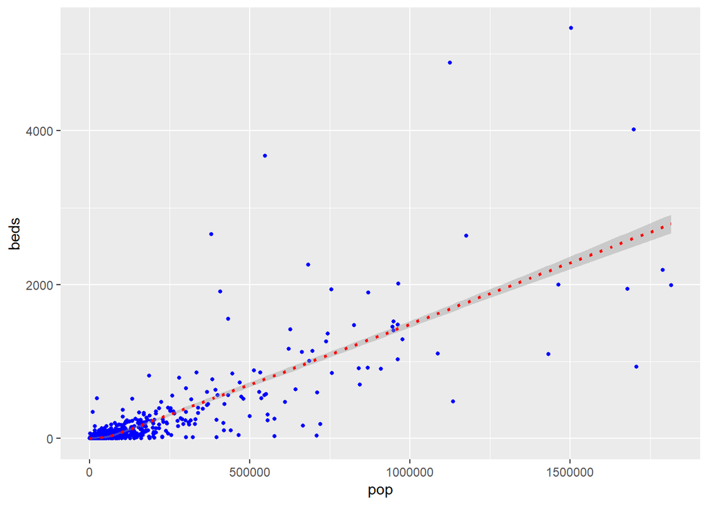

```r
ggplot(data=mundata,
       aes(x=pop, y=beds))+
  geom_point(color = "blue",
             size = 1)+
  geom_smooth(color = "red",
              linetype="dotted")
```

Para apreciar mejor el suavizador, restringimos a los municipios con más de 200,000 habitantes

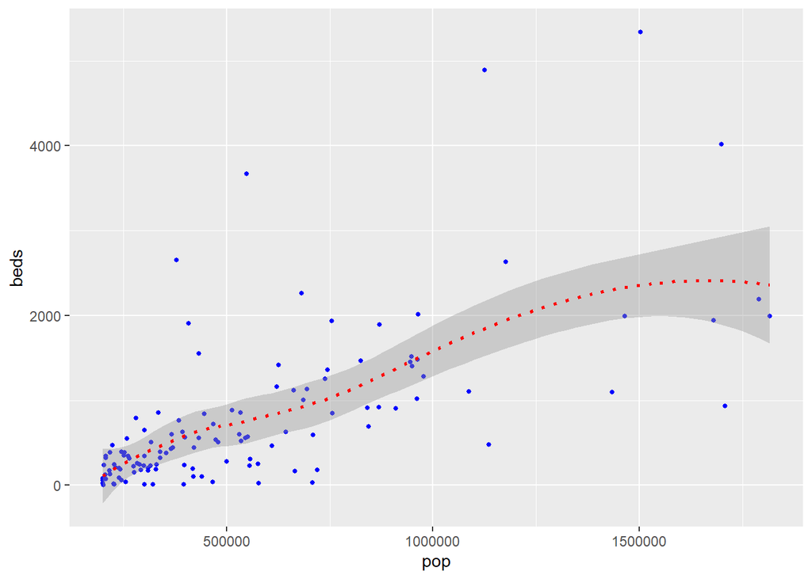

```r
ggplot(data=filter(mundata,pop>200000),
       aes(x=pop, y=beds))+
  geom_point(color = "blue",
             size = 1)+
  geom_smooth(color = "red",
              linetype="dotted")
```

# Facetas

A veces nos es útil graficar por grupos

```r
estados.norte <- c("Baja California",
                   "Baja California Sur",
                   "Chihuahua",
                   "Coahuila",
                   "Durango",
                   "Nuevo León",
                   "Sinaloa",
                   "Sonora",
                   "Tamaulipas")

estados.centro <- c("Ciudad de MÃ©xico",
                    "Guerrero",
                    "Hidalgo",
                    "MÃ©xico",
                    "Morelos",
                    "Puebla",
                    "Tlaxcala",
                    "Oaxaca")

estados.centroocc <- c("Aguascalientes",
                       "Colima",
                       "Guanajuato",
                       "Jalisco",
                       "MichoacÃ¡n",
                       "Nayarit",
                       "Querétaro",
                       "San Luis Potosí",
                       "Zacatecas")

estados.sureste <- c("Campeche",
                     "Chiapas",
                     "Quintana Roo",
                     "Tabasco",
                     "Veracruz",
                     "Yucatán")
```

Le asignamos el nombre de la región correspondiente:

```r
mundata <- mutate(mundata,
                  region=case_when(nom_ent %in% estados.norte ~ "Norte",
                                   nom_ent %in% estados.centro ~ "Centro",
                                   nom_ent %in% estados.centroocc ~ "Centro - occidente",
                                   nom_ent %in% estados.sureste ~ "Sureste"))
```

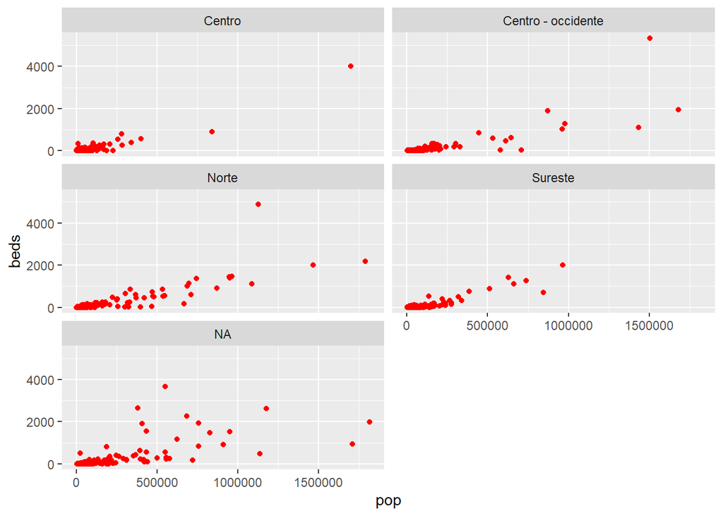

```r
ggplot(data=mundata,
       aes(x=pop, y=beds))+
  geom_point(color="red")+
  facet_wrap(~ region, ncol=2)
```

Recuerden que no es necesario poner siempre el nombre de los argumentos:

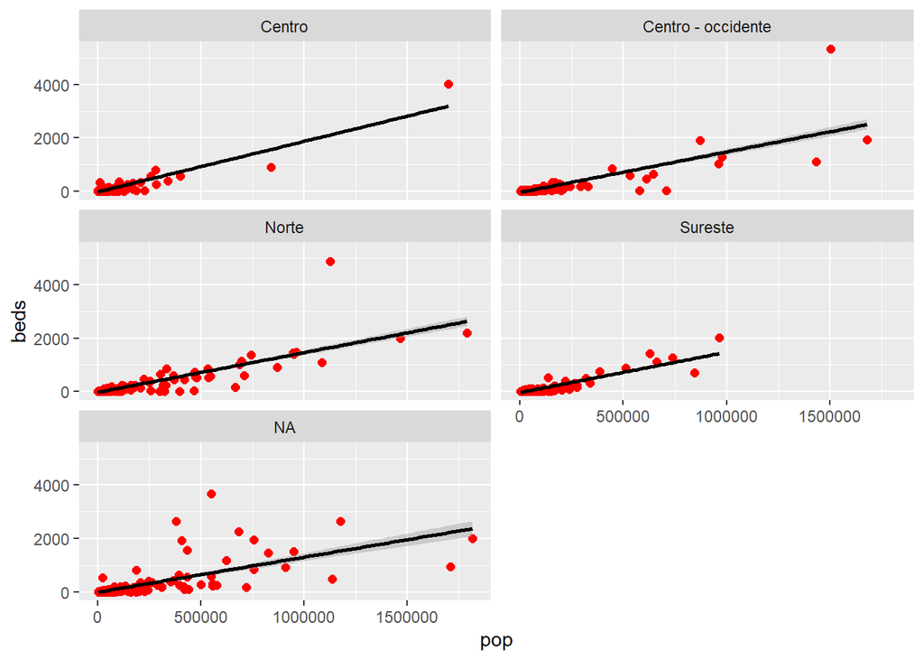

```r
ggplot(mundata,
       aes(pop, beds))+
  geom_point(color="red", size=2)+
  geom_smooth(method="lm", color="black")+
  facet_wrap(~ region, ncol=2)
```

## Gráficas de barras

Gráfico básico: cuenta el número de casos en cada categoría

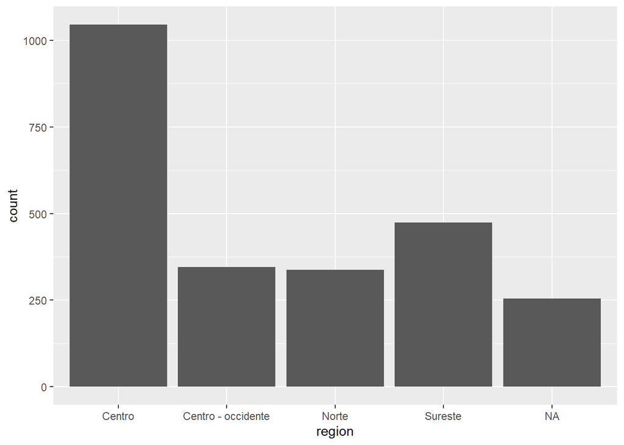

```r
ggplot(data=mundata)+
  geom_bar(aes(x=region))
```

De nuevo podemos modificar el color de relleno:

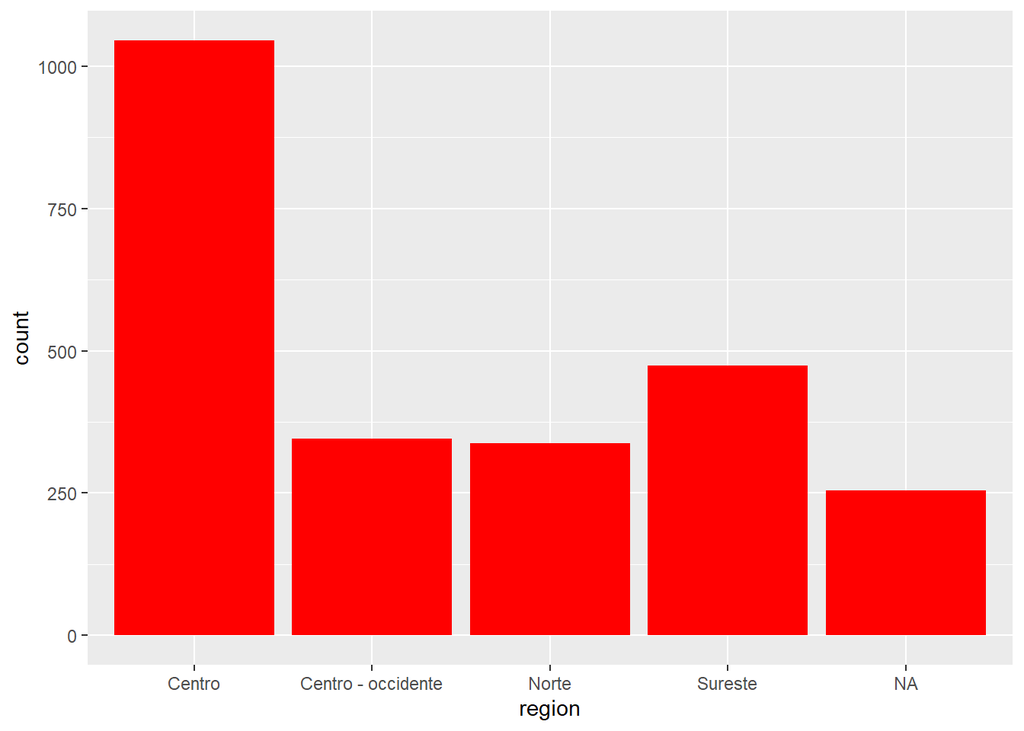

```r
ggplot(data=mundata)+
  geom_bar(aes(x=region),
           fill="red")
```

Y podemos poner la proporción:

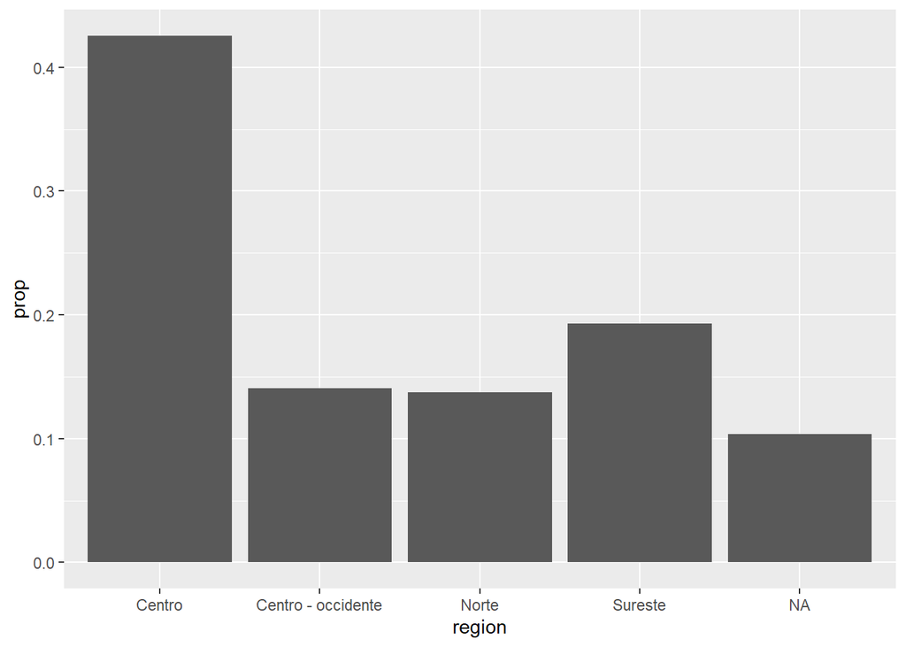

```r
ggplot(data=mundata)+
  geom_bar(aes(x=region,
               y=stat(prop),
               group=1))
```

Podemos hacer que cada barra tenga su color:

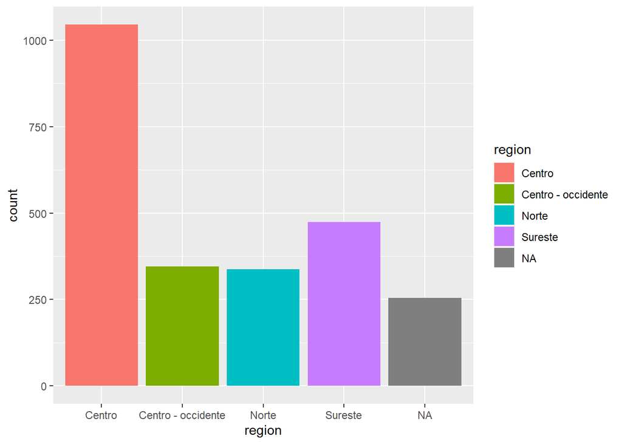

```r
ggplot(data=mundata)+
  geom_bar(aes(x=region,
               fill=region))
```

## Boxplot

Para que no haya tantos puntos, voy a usar solo municipios que se consideran parte del sistema urbano nacional

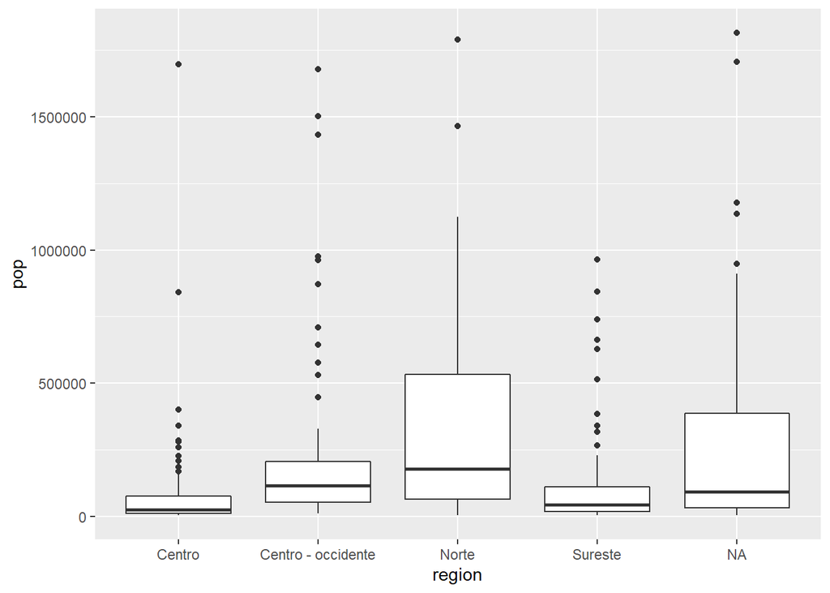

```r
ggplot(filter(mundata,!is.na(nom_sun))) +
  geom_boxplot(aes(region,pop))
```

A veces tiene sentido rotar los ejes

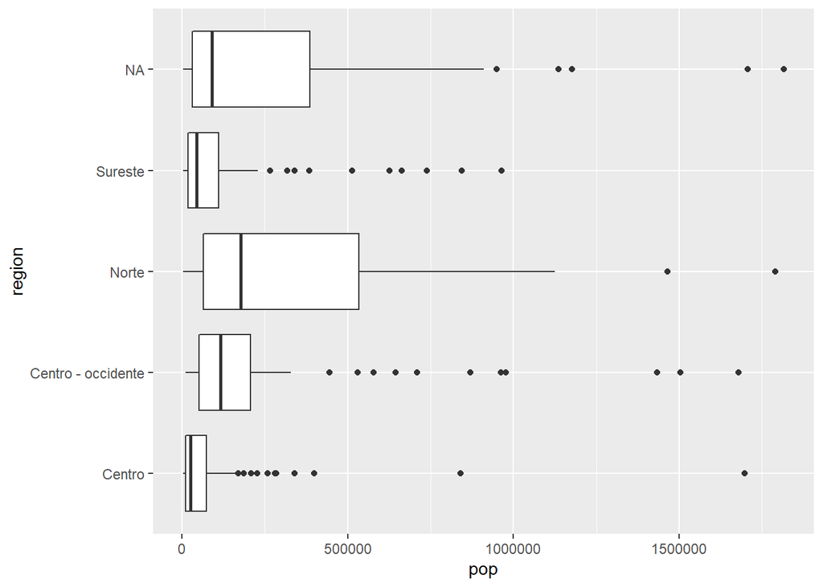

```r
ggplot(filter(mundata,!is.na(nom_sun))) +
  geom_boxplot(aes(region,pop))+
  coord_flip()
```

En *?geom_boxplot^* para saber más sobre esta grafíca:

- La caja: cuantiles 1 y 3 (25 y 75% de la distribuciÃ³n)
- Línea en medio de la caja: mediana
- Cada recta se extiende desde el extremo de la caja y hasta 1.5 veces el rango inter cuartil

Tenemos una base que reporta estadísticas agregadas de COVID-19 en México por oleada

```r
waves.data <- read_csv(file = "./waves_data.csv",
                       locale = locale(encoding = "latin1"))
```

## Estetica

Ahora exploremos como combinar la información de variables para dar formato a las gráficas. aes() controla la estetica

La estetica controla las propiedades visuales

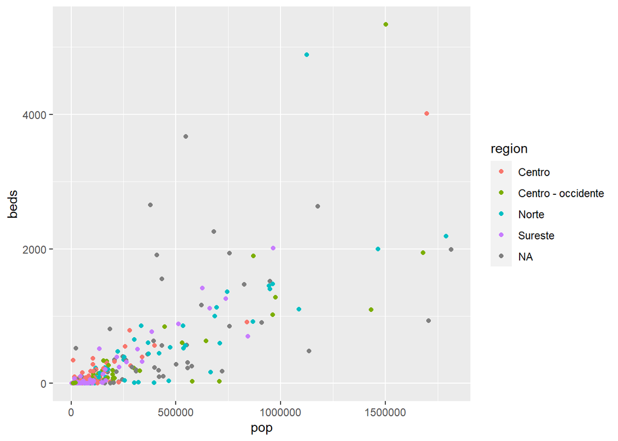

```r
ggplot(filter(mundata,!is.na(nom_sun)))+
  geom_point(mapping = aes(x=pop,
                           y=beds,
                           color=region))
```

Otra estetica es la forma del marcador

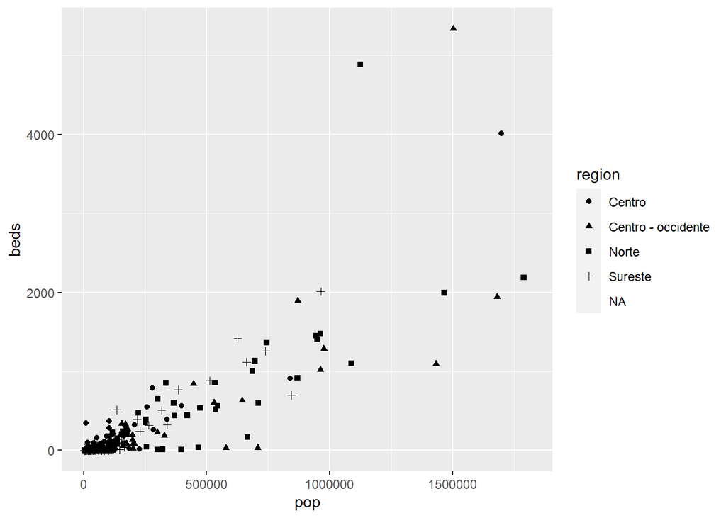

```r
ggplot(filter(mundata,!is.na(nom_sun)))+
  geom_point(mapping = aes(x=pop,
                           y=beds,
                           shape=region))
```

La transparencia del marcador

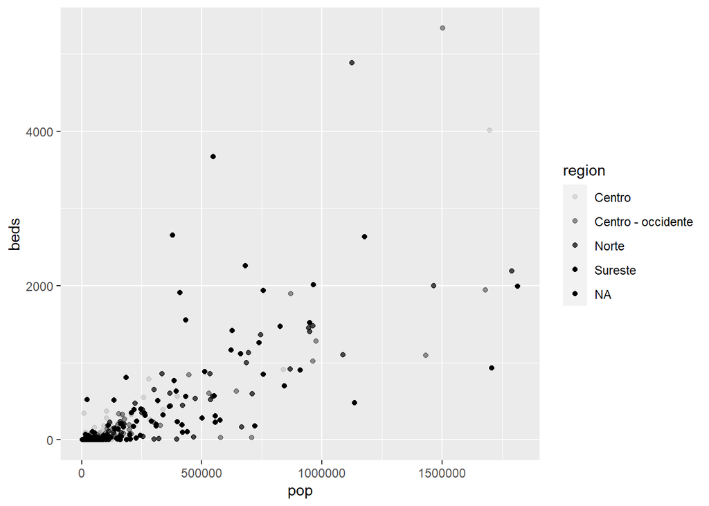

```r
ggplot(filter(mundata,!is.na(nom_sun)))+
  geom_point(mapping = aes(x=pop,
                           y=beds,
                           alpha=region))
```

Podemos combinarlos

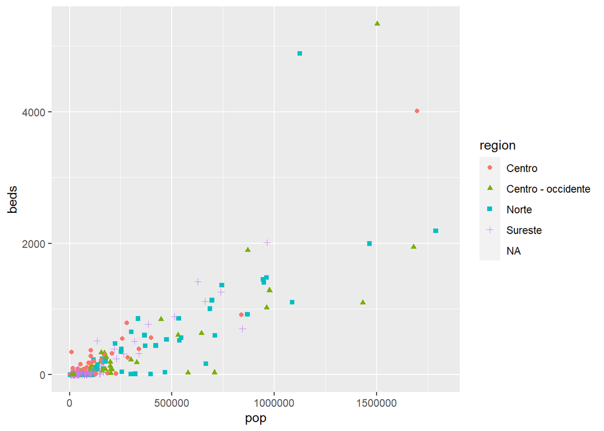

```r
ggplot(filter(mundata,!is.na(nom_sun)))+
  geom_point(mapping = aes(x=pop,
                           y=beds,
                           shape=region,
                           color=region))
```

## Histograma

Más empleado cuando tenemos una variable continua

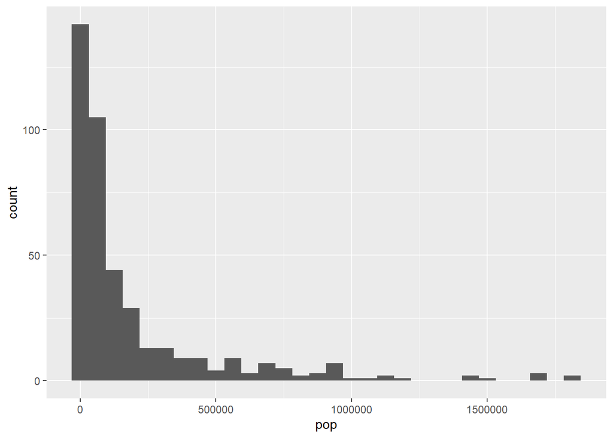

```r
ggplot(filter(mundata,!is.na(nom_sun)))+
  geom_histogram(aes(pop))
```

Binwidth controla el ancho de cada barra:

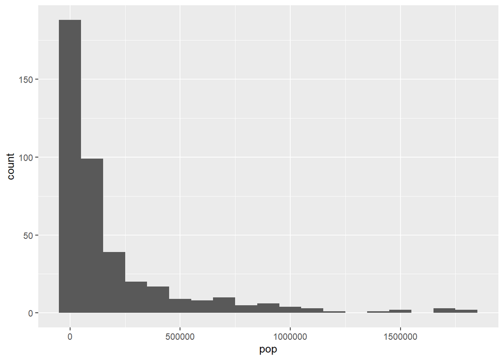

```r
ggplot(filter(mundata,!is.na(nom_sun)))+
  geom_histogram(aes(pop), binwidth = 100000)
```

Usamos lineas

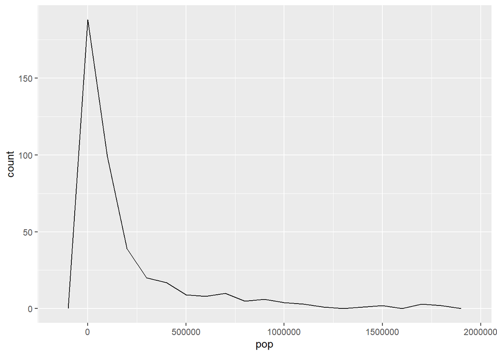

```r
ggplot(filter(mundata,!is.na(nom_sun)))+
  geom_freqpoly(aes(pop), binwidth = 100000)
```

Podemos usar ambos juntos

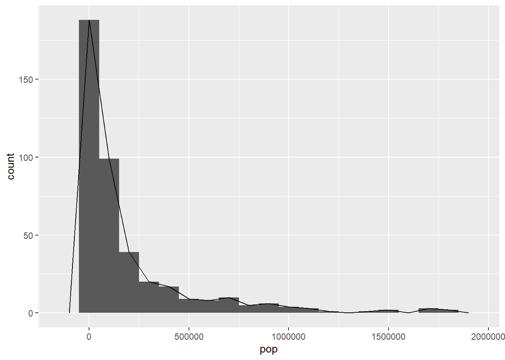

```r
ggplot(filter(mundata,!is.na(nom_sun)))+
  geom_histogram(aes(pop), binwidth = 100000)+
  geom_freqpoly(aes(pop), binwidth = 100000)
```

Agreguemos ahora una dimensión categórica

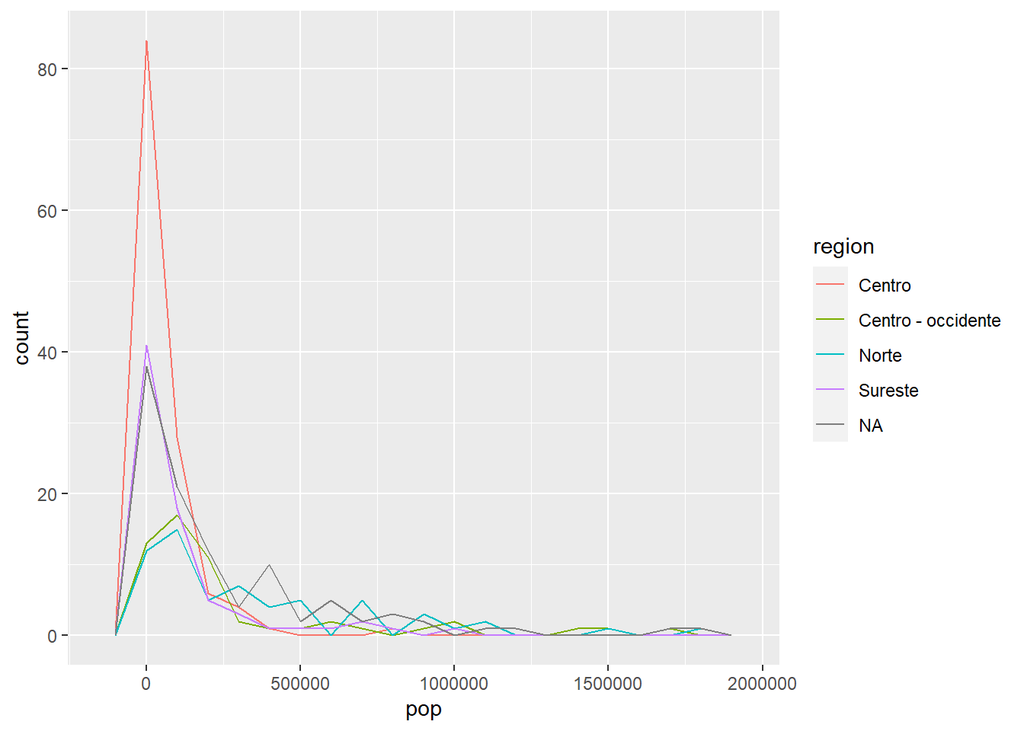

```r
ggplot(filter(mundata,!is.na(nom_sun)))+
  geom_freqpoly(aes(pop, color=region),
                binwidth = 100000)
```

Ahora con el tipo de línea

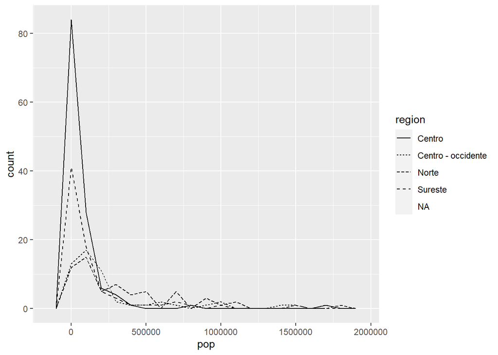

```r
ggplot(filter(mundata,!is.na(nom_sun)))+
  geom_freqpoly(aes(pop, linetype=region),
                binwidth = 100000)
```